# Quantitative Genetics

Multivariate Models

Felipe Ferrão

University of Florida – October, 2022

**Objectives:**

- 60 minutes of hands-on
- Multi-trait models, variance and covariance structures, heterogenues residuals

**Extra information**

- [PCB 6555 – Website](https://lfelipe-ferrao.github.io/class/quantGenetic/)
- About the [author](https://lfelipe-ferrao.github.io/)
- About the [UF/IFAS Plant Breeding](https://programs.ifas.ufl.edu/plant-breeding/)

# Introduction

Selection of in plant and animal breeding is usually based on a combination of several traits of economic importance. So far, we have analyzed traits individually using univariate models. After predicting the genetic values, we discussed that such can be combined using a selection index on which the individuals are ranked. In this section, we will modelling variance and covariance (var-cov) structures under two theoretical approaches:

1. Heterogeneous residual variance
2. Multi-response or multi-trait analysis

In this sense, we will introduce during this class some concepts related to multivariate analyses. Ideas here presented can be easily translated to multi-environment analyzes in the future.

# Introduction

## Why do we need Kronecker products?

In the [first class](https://htmlpreview.github.io/?https://github.com/lfelipe-ferrao/lfelipe-ferrao.github.io/blob/master/class/quantGenetic/week2a_2022.html) we discussed why is so important represent models using matrices.

Here we will introduce a new important concept: Kronecker product ($\otimes$). By definition, it is an operation on two matrices of arbitrary size resulting in a block matrix.

Look the example bellow. Let’s assume that we have 3 genotypes nested in two environments. The use of Kronecker product product allows us to specify a model where genotype within location effect have a correlation.
$$G_{LR} = \Sigma \otimes
I_g$$

$$= \begin{bmatrix} {\sigma^2_{a_1}}
& {\sigma^2_{a_{12}}} \\
{\sigma^2_{a_{12}}} & {\sigma^2_{a_{2}}}
\end{bmatrix} \otimes
\begin{bmatrix} {1} & {0} & {0} \\
{0} & {1} & {0}\\
{0} & {0} & {1} \end{bmatrix} =
\begin{bmatrix} {\sigma^2_{a_1}} & {0} & {0}
& {\sigma^2_{a_{12}}} & {0} & {0} \\
{0} & {\sigma^2_{a_1}} & {0} & {0} &
{\sigma^2_{a_{12}}} & {0} \\
{0} & {0} & {\sigma^2_{a_1}} & {0} &
{0} & {\sigma^2_{a_{12}}} \\
{\sigma^2_{a_{12}}} & {0} & {0} &
{\sigma^2_{a_{2}}} & {0} & {0} \\
{0} & {\sigma^2_{a_{12}}}& {0} & {0}
& {\sigma^2_{a_{2}}} & {0} \\
{0} & {0} & {\sigma^2_{a_{12}}} & {0}
& {0} & {\sigma^2_{a_{2}}} \\
\end{bmatrix}$$

For example:

- $x_{11}$ represents the genetic variance of the genotype 1 in the environment 1 and therefore the variance is $\sigma^2_{a_1}$.
- $x_{12}$ and $x_{13}$ are representing the genetic (co) variance between the genotype 1 and genotype 2 and 3 in the environment 1, respectively. Based on our assumptions, both genotypes are not correlated and therefore the (co) variance is null.
- $x_{14}$is where the real effect of the Kronecker products show up. It is representing the genetic (co)variance between the genotype 1 across the environment 1 and 2. Based on our assumptions, both environments are correlated and therefore the (co) variance is $\sigma^2_{a_{12}}$.

## Variance and Covariance Model Specifications

In plants and animal breeding, there are specific scenarios where the use of specific var-cov structures are essential. For example:

- We first evaluated the cases where the covariance between individuals in a population is known a priori through the specification of a kinship matrix.
- Another common scenario is when the residual of a linear model is not homogeneous and therefore ANOVA’s assumptions are not met. As a consequence a residual matrix with heterogeneous errors can be fitted.
- In the case of spacial analysis, where there is a spacial dependency for the residual
- Time series analyses, where there is a temporal dependency for the residuals

### Definition

Consider the following equation for a mixed linear model:

$$y = Xb + Za + e$$
$$var(y)=V = ZGZ'+ R$$

By default the variance of random effects is $G=I\sigma^2_u$ and the variance of residuals is $R=I\sigma^2_e$. However, there are other variance-covariance functions that can be tested and break this assumption of independence between variance components. For example:

| Model | Number Parameter | DEscription | asreml-R |
| --- | --- | --- | --- |
| Identity | 1 | Identical variation | `id` |
| Diagonal | M | Heterogeneous variations | `diag` |
| CS | 2 | Compound symmetry with homogeneous variance | interation model |
| CS Het | M+1 | Compound symmetry with heterogeneous variance | `corh` |
| AR1 | M+1 | First order autoregressive model | `ar1` |
| Unstructured | M(M+1)/2 | Unstructured model | `us` |

In a graphical representation, we will assume 4 genotypes that were evaluated in four different locations.

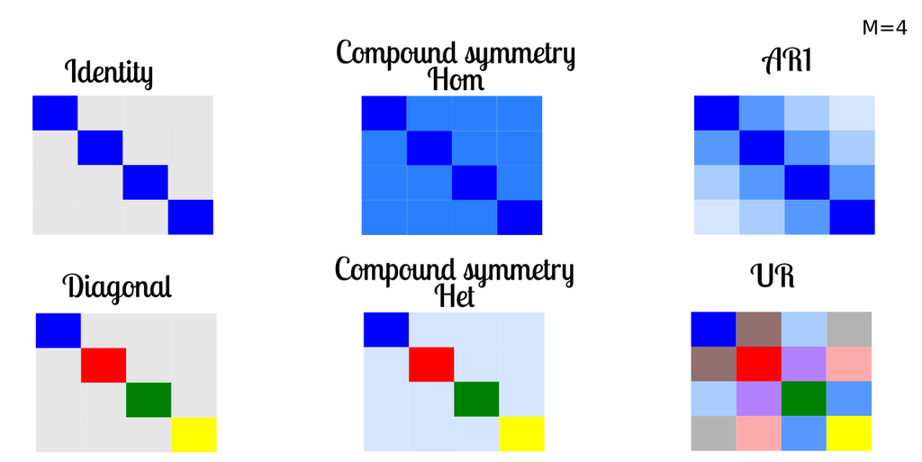

## Defining a Multivariate Model

A second case where modeling var-cov structures is important is when a genetic variation between traits must be estimated.

As originally presented by [Mrode (2014)](https://www.amazon.com/Linear-Models-Prediction-Animal-Breeding/dp/1845939816), the model for a multivariate analysis resembles a stack of the univariate models for each of the traits. For example, consider a multivariate analysis for two traits, with the following models for each trait:

$$y_1 = X_1b + Z_1a_1 + e_1$$
$$y_2 = X_2b + Z_2a_2 + e_2$$
$$\begin{bmatrix} {y_1} \\ {y_2} \end{bmatrix} =
\begin{bmatrix} {X_1} & {0}\\ {0} & {X_2} \end{bmatrix}
\begin{bmatrix} {b_1} \\ {b_2} \end{bmatrix} +
\begin{bmatrix} {Z_1} & {0}\\ {0} & {Z_2} \end{bmatrix}
\begin{bmatrix} {u_1} \\ {u_2} \end{bmatrix} +
\begin{bmatrix} {e_1} \\ {e_2} \end{bmatrix}$$

- $y_i$ = vector of observations for the ith trait;
- $b_i$ = vector of fixed effects for the ith trait;
- $a_i$ = vector of random animal effects for the ith trait;
- $e_i$ = vector of random residual effects for the ith trait;
- $X_i$ and $Z_i$ = incidence matrices relating records of the ith trait to fixed and random animal effects.

The use of these equations will change the form of the residual (**R**) and the genetic (**G**) matrices. Assuming that pedigree information is presented (**A**), in the case of two traits, multivariate models can be used to estimate genetic an residuals components for each trait, as follow:

$$var\begin{bmatrix} {a_1} \\ {a_2} \\ {e_1} \\ {e_2} \end{bmatrix} =
\begin{bmatrix} {g_{11}A} & {g_{12}A} & {0} &{0} \\
{g_{21}A} & {g_{22}A} & {0} &{0} \\
0 & 0 & {r_{11}} &{r_{12}} \\
0 & 0 & {r_{21}} &{r_{22}} \\
\end{bmatrix}$$
Same assumptions are more commonly reported as Kronecker product in the following way:

$$G = \begin{bmatrix} {\sigma^2_{a_1}} & {\sigma^2_{a_{12}}} \\
{\sigma^2_{a_{12}}} & {\sigma^2_{a_{2}}}
\end{bmatrix} \otimes A;
R = I \otimes \begin{bmatrix} {\sigma^2_{e_1}} & {\sigma^2_{e_{12}}}
\\
{\sigma^2_{e_{12}}} & {\sigma^2_{e_{2}}}
\end{bmatrix}$$

The mixed model equation have a similar form that presented when the Animal Model was discussed:

$$\begin{bmatrix} {X'R^{-1}X} & {X'R^{-1}Z} \\ {Z'R^{-1}X}
& {Z'R^{-1}Z} + {A^{-1}G^{-1}} \end{bmatrix}
\begin{bmatrix} {\hat{b}}\\ {\hat{a}} \end{bmatrix}
=
\begin{bmatrix} {X'R^{-1}y} \\ {Z'R^{-1}y} \end{bmatrix}$$

**Advantages of multi-trait models**:

- Breeding values (EBVs) estimated from multivariate models for low heritability traits receive an increase in accuracy by exploiting their covariances with higher heritability traits.
- Genetic correlation estimates via multivariate models are useful to understand how different traits are genetically related to fitness.
- Increase in accuracy with multivariate analysis resulting from better connections in the data due to residual covariance between traits

# Hands-on

- Heterogeneous R variance structures in a coffee data set
- Multi-trait model in a maize data set

## Coffee data set

- Download the coffee data set (`coffee_FEM_int.csv`).
  - [Original paper](https://www.nature.com/articles/s41437-018-0105-y).
  - Description: 119 genotypes from multiple crosses performed in coffee. Genotypes were grown in experimental units (plots) of 5 plants each using a randomized complete block design with three replications at each of four years. Coffee beans were harvested and the total yield (kg) per plot forthe five plants within each plot was measured. Yield is the independent variable used for this experiment.

| Effect | Observation | Levels |
| --- | --- | --- |
| year | year in which the plants were evaluated | 4 |
| block | replication number | 3 |
| trat | coffee genotype | 119 |
| yield | total yield (kg) per plot | numeric |
| Numb.Plants | number of plants evaluated per plot | numeric |

**Model**

- Breeding and genetics experiments often have natural groupings of observations (such as environments, or ages of individuals, or years of evaluation) that may differ in terms of their error variation.
- Such trends are mostly observed when the residual diagnostic is performed.

$$y_{ijk} = \mu + L_i + B(L)_{ij} +
\underline{G_k} + \underline{GL_{ik}} + \underline{e_{ijk}}$$

- $\mu$ is the overall mean;
- $L_i$ = effect of year i
- $B(L)_{ij}$ = effect of block j nested within year i
- $G_k$ = random effect of genotype k, where $G_{k} \sim N(0, I\sigma^2_g)$
- $GL_{ik}$ = random effect of interaction between genotype k and year i, where $GL_{ik} \sim N(0, I\sigma^2_{g \times e})$
- Homogeneous variance models

$$R=\sigma^2_eI_{476} =
\sigma^2_ e \begin{bmatrix} {1} & \dots & {0}\\
\vdots & \ddots & \vdots \\
{0} & \dots & {1}
\end{bmatrix} =
\begin{bmatrix} {\sigma^2_ e} & \dots
& {0}\\
\vdots & \ddots & \vdots \\
{0} & \dots & {\sigma^2_ e}
\end{bmatrix}$$

- Heterogeneous R variance structures (diagonal structure)

$$R=\sigma^2_{e_i} R_j =
\sigma^2_{e_i} \begin{bmatrix} {R_1} & {0} & {0} & {0}\\
{0} & {R_2} & {0} & {0}\\
{0} & {0} & {R_3} & {0}\\
{0} & {0} & {0} & {R_4}\\
\end{bmatrix} =
\begin{bmatrix} {\sigma^2_{e1}I_{119}}
& {0} & {0} & {0}\\
{0} & {\sigma^2_{e2}I_{119}} & {0}
& {0}\\
{0} & {0} & {{\sigma^2_{e3}}I_{119}}
& {0}\\
{0} & {0} & {0} &
{{\sigma^2_{e4}}I_{119}}\\
\end{bmatrix}$$

**Codes**

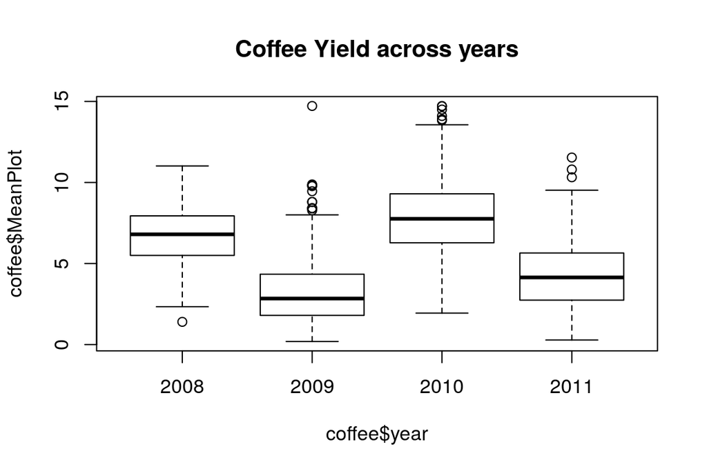

```r
##################
# Coffee data set
#################
library(asreml)
library(dplyr)
library(gridExtra)

coffee = read.csv("/home/lferrao/Dropbox (UFL)/classes/QuantitativeGenetics_22/Class9_MultivariateModels/coffee_FES_int.csv", h=T, colClasses = c("factor", "factor", "numeric", "numeric", "factor"))
#head(coffee)

# Mean value per plot
coffee = coffee %>%mutate(MeanPlot = yield/Numb.Plants)

# Plots
boxplot(coffee$MeanPlot~coffee$year, main="Coffee Yield across years")
```

```r
# Models
m1 = asreml(MeanPlot ~  block%in%year + year,
        random= ~ trat+trat:year,
        data=coffee)
```

```
## Model fitted using the gamma parameterization.
## ASReml 4.1.0 Thu Nov  3 08:28:10 2022
##           LogLik        Sigma2     DF     wall    cpu
##  1     -1602.770       3.03852   1397 08:28:10    0.0
##  2     -1580.948       2.76052   1397 08:28:10    0.0
##  3     -1563.217       2.48286   1397 08:28:10    0.0
##  4     -1556.680       2.31838   1397 08:28:10    0.0
##  5     -1555.556       2.24689   1397 08:28:10    0.0
##  6     -1555.537       2.24080   1397 08:28:10    0.0
##  7     -1555.537       2.24067   1397 08:28:10    0.0
```

```r
summary(m1)$varcomp
```

```
##           component std.error   z.ratio bound %ch
## trat      0.8612405 0.1735564  4.962308     P   0
## trat:year 1.0232149 0.1385738  7.383897     P   0
## units!R   2.2406665 0.1041407 21.515755     P   0
```

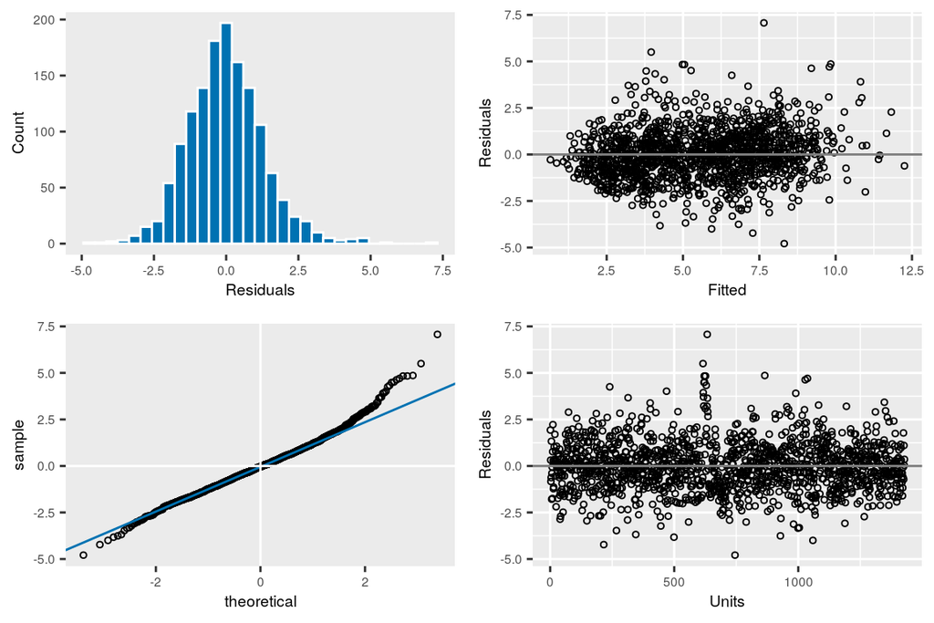

```r
plot(m1)
```

```r
m2 = asreml(MeanPlot ~  block%in%year + year,
        random= ~ trat+trat:year,
        residual=~dsum(~id(units)|year),
        data=coffee)
```

```
## Multi-section model using the sigma parameterization.
## ASReml 4.1.0 Thu Nov  3 08:28:11 2022
##           LogLik        Sigma2     DF     wall    cpu
##  1     -1598.412           1.0   1397 08:28:11    0.0
##  2     -1574.504           1.0   1397 08:28:11    0.0
##  3     -1551.730           1.0   1397 08:28:11    0.0
##  4     -1542.236           1.0   1397 08:28:11    0.0
##  5     -1540.524           1.0   1397 08:28:11    0.0
##  6     -1540.497           1.0   1397 08:28:11    0.0
##  7     -1540.497           1.0   1397 08:28:11    0.0
```

```r
summary(m2)$varcomp
```

```
##             component std.error   z.ratio bound %ch
## trat        0.8837616 0.1774448  4.980487     P   0
## trat:year   1.0673308 0.1385903  7.701338     P   0
## year_2008!R 2.0360199 0.1813008 11.230065     P   0
## year_2009!R 2.8876442 0.2575037 11.213992     P   0
## year_2010!R 2.4926510 0.2276528 10.949354     P   0
## year_2011!R 1.4550420 0.1369233 10.626691     P   0
```

```r
# Goodness of fit
summary(m1)$aic
```

```
## [1] 3117.074
## attr(,"parameters")
## [1] 3
```

```r
summary(m2)$aic
```

```
## [1] 3092.993
## attr(,"parameters")
## [1] 6
```

[figure not shown]

```r
# BLUPs
# blups.m1 = predict(m1, class="trat")$pvals
# blups.m2 = predict(m2, class="trat")$pvals
# plot(blups.m1$predicted.value,blups.m2$predicted.value)
```

## Maize data set

- Download the maize file(`MaizeRILs.csv` data).
  - [Link for the example](https://drive.google.com/drive/folders/0B9JWAJgh6v3Cflppc09XUXU3WHRvX29qY1IxNDVFaEdpblA4SFNXOThQV2ZDRVkxWlZWSEk).
  - Description: 62 recombinat inbreed lines (RIL) progeny from the crosses between inbred maize lines B73 and MO17. RILS were grown in experimenal units using a RCBD desing with two replications and four locations.

| Effect | Observation | Levels |
| --- | --- | --- |
| location | location of the progeny test | 4 |
| rep | replication number | 2 |
| block | block number | 8 |
| plot | plot number | numeric |
| RIL | treatment -- recombination inbred line ID | 62 |
| pollen | days to pollen shed | numeric |
| silking | days to silking | numeric |
| height | mean height of five plants in each plot | numeric |

- There are three traits for which we are interested in estimating variances and genetic correlations: days to pollen shed (pollen), days to silking (silking) and mean height of the five plants in each plot (height).
- This model is an example where we can estimate the genotypic variances and covariances.

**Univariate version**

$$y_{ijk} = \mu + L_i +
\underline{B(L)_{ij}} + \underline{G_k} + \underline{GL_{ik}} +
\underline{e_{ijk}}$$

- $\mu$ is the overall mean;
- $L_i$ = effect of location i
- $B(L)_{ij}$ = effect of block j nested within location i
- $G_k$ = effect of genotype k
- $GL_{ik}$ = effect of interaction between genotype k and location i
- $e_{ijk}$ = random effect error, distributed as: $e_{ijk} \sim N(0, I\sigma^2_e)$

**Simplified matrix notation**

$$y_i = X_i\beta_i + Z_iu_i +
\varepsilon_i$$

$$\begin{bmatrix}
y_{1} \\
y_{2} \\
y_{3} \\
\end{bmatrix}
=
\begin{bmatrix}
X_{1} &0 & ... & 0 \\
0 & X_{2} & ...& 0 \\
0& 0& ... & X_{3} \\
\end{bmatrix}
\begin{bmatrix}
\beta_{1} \\
\beta_{2} \\
\beta_{3} \\
\end{bmatrix}
+
\begin{bmatrix}
Z_{1} &0 & ... & 0 \\
0 & Z_{2} & ...& 0 \\
0& 0& ... & Z_{3} \\
\end{bmatrix}
\begin{bmatrix}
u_{1} \\
u_{2} \\
u_{3} \\
\end{bmatrix}
+
\begin{bmatrix}
\varepsilon_1 \\
\varepsilon_2 \\
\varepsilon_3 \\
\end{bmatrix}$$

$$y|\beta, u, G_0, R_0 \sim \mathcal{N}
(X\beta + Zu, R_0 \otimes I)$$

### Important Information

- Multivariate are complex models, in which multiple parameters are estimated at the same time – high computational demand.
- A general pipeline is:
  - Standardize all response variables
  - Always start fitting single trait (univariate) models
  - Estimate the `varcomp` values in the single trait analysis – they are good starting values and can help in the multivariate version
  - In the multivariate version, start by testing a simple var-cov structures
  - Move to more complex var-cov models and check the %CPU used (it is common crash the system)

**Codes**

In this demo we will test four different model structures.

1. `m.height`, `m.silking` and `m.pollen` are single trait (univariate) versions.
2. `m.diag`: is a multi-trait version, where we a assume a simple var-cov (diag) for the genetic term and a complex structure (us) for the residual. Important: in this model we assume that traits are not genetically correlated.

$$R_0=
\begin{bmatrix}
\sigma^2_{e_1} & \sigma^2_{e_{12}} & \sigma^2_{e_{13}}\\
\sigma^2_{e_{21}} & \sigma^2_{e_2} & \sigma^2_{e_{23}}\\
\sigma^2_{e_{31}} & \sigma^2_{e_{32}} & \sigma^2_{e_{3}}\\
\end{bmatrix}
; G_0=
\begin{bmatrix}
\sigma^2_{u_1} & 0 & 0\\
0 & \sigma^2_{u_2} & 0\\
0 & 0 & \sigma^2_{u_{3}}\\
\end{bmatrix}$$

3. `m.diag.init`: same model as before, but using initial values. This is an alternative to improve software convergence
4. `m.us.init`: we assume complex var-cov for the genetic and residual terms. Here, genetic correlations are computed between traits.

$$R_0=
\begin{bmatrix}
\sigma^2_{e_1} & \sigma^2_{e_{12}} & \sigma^2_{e_{13}}\\
\sigma^2_{e_{21}} & \sigma^2_{e_2} & \sigma^2_{e_{23}}\\
\sigma^2_{e_{31}} & \sigma^2_{e_{32}} & \sigma^2_{e_{3}}\\
\end{bmatrix}
; G_0=
\begin{bmatrix}
\sigma^2_{u_1} & \sigma^2_{u_{12}} & \sigma^2_{u_{13}}\\
\sigma^2_{u_{21}} & \sigma^2_{u_2} & \sigma^2_{u_{23}}\\
\sigma^2_{u_{31}} & \sigma^2_{u_{32}} & \sigma^2_{u_{3}}\\
\end{bmatrix}$$

**Important**

When specifying initial values in complex var-cov structures (ex: unstructured form) values should be imputed as a triangular matrix. In the example below we have tree traits. The number represents the order in which the values should be imputed. For example, $x1$ represents the first value that should be imputed and in this case is the variance associated to the trait 1; $x_2$ is the second value and in this format represents the covariance between trait 1 and trait2.

$$\Sigma_{uns}=
\begin{bmatrix}
x_1 & & \\
x_2 & x_3 & \\
x_4 & x_5 & x_6\\
\end{bmatrix}$$

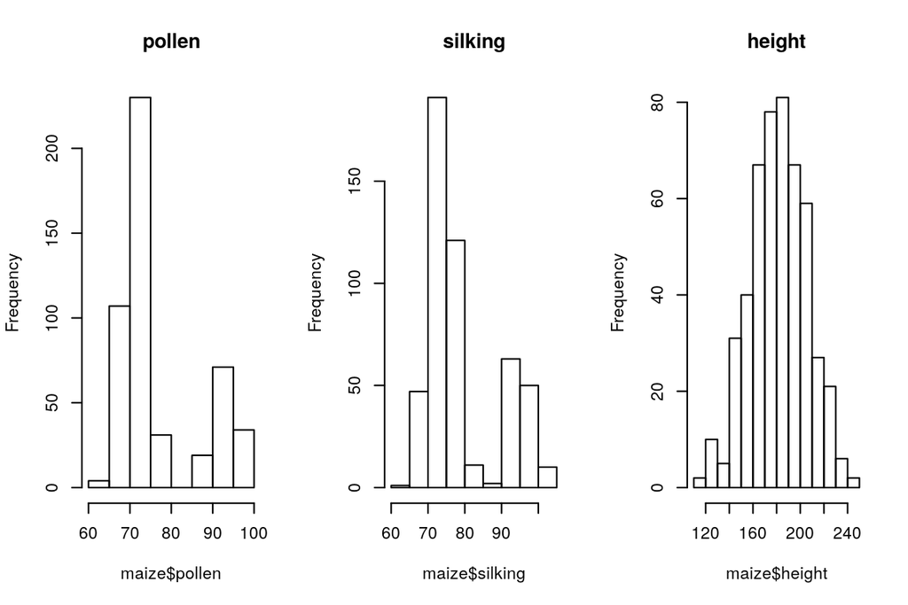

```r
##################
# Multi trait maize
###################
library(asreml)
maize = read.csv("/home/lferrao/Dropbox (UFL)/classes/QuantitativeGenetics_22/Class9_MultivariateModels/MaizeRILs.csv", h=T)
maize$rep = as.factor(maize$rep)
maize$RIL = as.factor(maize$RIL)
maize$location = as.factor(maize$location)

# Traits
par(mfrow=c(1,3))
hist(maize$pollen, main="pollen")
hist(maize$silking, main="silking")
hist(maize$height, main="height")
```

```r
#########
# Univariate Model
#####

# First univariate models
m.height = asreml(height ~location,
        random= ~ rep:location + RIL + RIL:location,
        data=maize)
```

```
## Model fitted using the gamma parameterization.
## ASReml 4.1.0 Thu Nov  3 08:47:22 2022
##           LogLik        Sigma2     DF     wall    cpu
##  1     -1631.102       226.219    492 08:47:22    0.0
##  2     -1556.502       136.090    492 08:47:22    0.0
##  3     -1496.596        94.132    492 08:47:22    0.0
##  4     -1465.530        77.054    492 08:47:22    0.0
##  5     -1453.521        68.619    492 08:47:22    0.0
##  6     -1451.500        65.663    492 08:47:22    0.0
##  7     -1451.384        64.941    492 08:47:22    0.0
##  8     -1451.384        64.887    492 08:47:22    0.0
```

```r
m.silking = asreml(silking ~location,
        random= ~ rep:location + RIL + RIL:location,
        data=maize)
```

```
## Model fitted using the gamma parameterization.
## ASReml 4.1.0 Thu Nov  3 08:47:22 2022
##           LogLik        Sigma2     DF     wall    cpu
##  1      -723.573       5.65400    492 08:47:22    0.0
##  2      -693.439       4.49328    492 08:47:22    0.0
##  3      -666.852       3.62232    492 08:47:22    0.0
##  4      -652.697       3.18377    492 08:47:22    0.0
##  5      -647.735       2.96408    492 08:47:22    0.0
##  6      -647.214       2.89762    492 08:47:22    0.0
##  7      -647.203       2.88776    492 08:47:22    0.0
```

```r
m.pollen = asreml(pollen ~location,
        random= ~ rep:location + RIL + RIL:location,
        data=maize)
```

```
## Model fitted using the gamma parameterization.
## ASReml 4.1.0 Thu Nov  3 08:47:22 2022
##           LogLik        Sigma2     DF     wall    cpu
##  1      -632.711       3.90791    492 08:47:22    0.0
##  2      -567.065       2.40773    492 08:47:22    0.0
##  3      -514.246       1.67718    492 08:47:22    0.0
##  4      -486.043       1.38480    492 08:47:22    0.0
##  5      -475.168       1.24157    492 08:47:22    0.0
##  6      -473.421       1.19173    492 08:47:22    0.0
##  7      -473.331       1.18012    492 08:47:22    0.0
##  8      -473.331       1.17934    492 08:47:22    0.0
```

```r
# Variance components
data.frame(height= summary(m.height)$varcomp[,1],
           pollen = summary(m.pollen)$varcomp[,1],
           silking = summary(m.silking)$varcomp[,1],
           row.names = rownames(summary(m.height)$varcomp))
```

```
##                 height    pollen   silking
## rep:location  13.44636 0.4496973 0.6629308
## RIL          303.15261 4.8900095 4.9922524
## RIL:location  24.93243 0.5732545 0.8370813
## units!R       64.88656 1.1793400 2.8877620
```

```r
#########
# Multivariate Model
#####

# We should start with a relatively simple multivariate model
# Diagonal var-cov structure
# Trait effect is the multivariate version, it allows us to stack of the univariate models
# All fixed effects and random effects should involve an interaction with trait to create appropriate design matrices for the effects.

m.diag<-asreml(fixed=cbind(height,pollen,silking)~trait+trait:location,
               random=~ diag(trait):RIL +
                        diag(trait):(RIL:location) +
                        diag(trait):(rep:location),
               residual = ~id(units):us(trait),
                 data=maize)
```

```
## Model fitted using the sigma parameterization.
## ASReml 4.1.0 Thu Nov  3 08:47:22 2022
##           LogLik        Sigma2     DF     wall    cpu
##  1     -3813.987           1.0   1476 08:47:22    0.0 (13 restrained)
##  2     -3565.756           1.0   1476 08:47:22    0.0 (13 restrained)
##  3     -3441.276           1.0   1476 08:47:22    0.0 (13 restrained)
##  4     -3361.787           1.0   1476 08:47:22    0.0 (13 restrained)
##  5     -3308.825           1.0   1476 08:47:22    0.0 (10 restrained)
##  6     -3305.735           1.0   1476 08:47:22    0.0 (13 restrained)
##  7     -3279.070           1.0   1476 08:47:22    0.0 (7 restrained)
##  8     -2749.403           1.0   1476 08:47:22    0.0 (4 restrained)
##  9     -2574.938           1.0   1476 08:47:22    0.0 (1 restrained)
## 10     -2536.604           1.0   1476 08:47:22    0.0
## 11     -2529.077           1.0   1476 08:47:22    0.0
## 12     -2528.461           1.0   1476 08:47:22    0.0
## 13     -2528.450           1.0   1476 08:47:22    0.0
```

```r
m.diag = update.asreml(m.diag)
```

```
## Model fitted using the sigma parameterization.
## ASReml 4.1.0 Thu Nov  3 08:47:22 2022
##           LogLik        Sigma2     DF     wall    cpu
##  1     -2528.450           1.0   1476 08:47:23    0.0
##  2     -2528.450           1.0   1476 08:47:23    0.0
```

```r
var.comp = summary(m.diag)$varcomp
var.comp
```

```
##                                     component  std.error    z.ratio bound %ch
## trait:rep:location!trait_height    13.3383822 10.1813458  1.3100805     P 0.0
## trait:rep:location!trait_pollen     0.4212160  0.3136585  1.3429130     P 0.0
## trait:rep:location!trait_silking    0.6074751  0.4678141  1.2985396     P 0.0
## trait:RIL!trait_height            304.2528039 57.6606700  5.2766089     P 0.0
## trait:RIL!trait_pollen              4.7209842  0.8990450  5.2511098     P 0.0
## trait:RIL!trait_silking             4.8798031  0.9720238  5.0202505     P 0.0
## trait:RIL:location!trait_height    23.4412192  6.5502768  3.5786609     P 0.0
## trait:RIL:location!trait_pollen     0.2751359  0.1018304  2.7019039     P 0.1
## trait:RIL:location!trait_silking    0.2480891  0.2140713  1.1589085     P 0.1
## units:trait!R                       1.0000000         NA         NA     F 0.0
## units:trait!trait_height:height    65.7349845  5.9606219 11.0282091     P 0.0
## units:trait!trait_pollen:height     0.5146264  0.5465002  0.9416765     P 0.1
## units:trait!trait_pollen:pollen     1.3985305  0.1238987 11.2876970     P 0.0
## units:trait!trait_silking:height   -1.4564994  0.8239301 -1.7677464     P 0.0
## units:trait!trait_silking:pollen    1.0354748  0.1295961  7.9900139     P 0.0
## units:trait!trait_silking:silking   3.3715938  0.2971200 11.3475812     P 0.0
```

```r
# Covariance matrix for the traits (diagonal structure)
var.comp[grep("trait:RIL!",rownames(var.comp)),]
```

```
##                          component  std.error  z.ratio bound %ch
## trait:RIL!trait_height  304.252804 57.6606700 5.276609     P   0
## trait:RIL!trait_pollen    4.720984  0.8990450 5.251110     P   0
## trait:RIL!trait_silking   4.879803  0.9720238 5.020251     P   0
```

```r
# s | 4.8   0    0  |
# p |  0    4.7  0  |
# h |  0    0   304 |

# We assumed no genetic correlations between traits

# Residual variance (unstructure structure)
var.comp[grep("units:trait!",rownames(var.comp)),]
```

```
##                                    component std.error    z.ratio bound %ch
## units:trait!R                      1.0000000        NA         NA     F 0.0
## units:trait!trait_height:height   65.7349845 5.9606219 11.0282091     P 0.0
## units:trait!trait_pollen:height    0.5146264 0.5465002  0.9416765     P 0.1
## units:trait!trait_pollen:pollen    1.3985305 0.1238987 11.2876970     P 0.0
## units:trait!trait_silking:height  -1.4564994 0.8239301 -1.7677464     P 0.0
## units:trait!trait_silking:pollen   1.0354748 0.1295961  7.9900139     P 0.0
## units:trait!trait_silking:silking  3.3715938 0.2971200 11.3475812     P 0.0
```

```r
# s | 3.3     1.0     -1.4   |
# p | 1.0     1.39     0.51  |
# h | -1.4    0.51     65    |

# Diagonal: residual variances for height, pollen and silking.
# Off-diag: residual correlations different traits

# ---- # ---#
# Observations:
# i) Convergence to globally optimal parameter values becomes more difficult
# ii) Choice of starting values becomes more important
# iii) The model requires estimates of 15 parameters. 6 only for the residual
# vi) We did not standardized the traits (following book's example)

#########
# Multivariate Model with initial values
#####

# As models become more complex, good initial values may be necessary to achieve convergence.
# We will use same model, but with initial values
# Initial values come from the univariate model

# Unstructure initial values (triangular form)
# s | 64.9          |
# p | 0   1.17       |
# h | 0   0    2.89   |

init.rep.loc<-c(13.44,0.44,0.66)
init.ril<-c(303.15,4.9,4.992)
init.ril.loc<-c(24.93, 0.573, 0.837)
init.res = c(64.9,0,1.179,0,0,2.89) # triangular matrix

m.diag.init<-asreml(fixed=cbind(height,pollen,silking)~trait+trait:location,
                    random=~ diag(trait,init = init.ril):RIL +
                            diag(trait,init = init.ril.loc):(RIL:location) +
                            diag(trait,init=init.rep.loc):(rep:location),
                    residual = ~id(units):us(trait,init=init.res),
                 data=maize)
```

```
## Model fitted using the sigma parameterization.
## ASReml 4.1.0 Thu Nov  3 08:47:23 2022
##           LogLik        Sigma2     DF     wall    cpu
##  1     -2571.916           1.0   1476 08:47:23    0.0 (3 restrained)
##  2     -2571.882           1.0   1476 08:47:23    0.0 (3 restrained)
##  3     -2571.354           1.0   1476 08:47:23    0.0 (3 restrained)
##  4     -2563.137           1.0   1476 08:47:23    0.0 (1 restrained)
##  5     -2565.192           1.0   1476 08:47:23    0.0
##  6     -2543.103           1.0   1476 08:47:23    0.0
##  7     -2531.331           1.0   1476 08:47:23    0.0
##  8     -2528.496           1.0   1476 08:47:23    0.0
##  9     -2528.450           1.0   1476 08:47:23    0.0
## 10     -2528.450           1.0   1476 08:47:23    0.0
```

```r
var.comp.init = summary(m.diag.init)$varcomp
var.comp.init[grep("trait:RIL!",rownames(var.comp.init)),]
```

```
##                          component  std.error  z.ratio bound %ch
## trait:RIL!trait_height  304.253027 57.6611001 5.276573     P   0
## trait:RIL!trait_pollen    4.721040  0.8991556 5.250526     P   0
## trait:RIL!trait_silking   4.879857  0.9721359 5.019727     P   0
```

```r
var.comp.init[grep("units:trait!",rownames(var.comp.init)),]
```

```
##                                    component std.error    z.ratio bound %ch
## units:trait!R                      1.0000000        NA         NA     F 0.0
## units:trait!trait_height:height   65.7343834 5.9602658 11.0287671     P 0.0
## units:trait!trait_pollen:height    0.5144557 0.5464376  0.9414721     P 0.1
## units:trait!trait_pollen:pollen    1.3984571 0.1238688 11.2898271     P 0.0
## units:trait!trait_silking:height  -1.4565109 0.8238491 -1.7679341     P 0.0
## units:trait!trait_silking:pollen   1.0353700 0.1295772  7.9903710     P 0.0
## units:trait!trait_silking:silking  3.3714374 0.2970481 11.3498014     P 0.0
```

```r
# Observations:
# i) No convergence issues
# ii) Initial values provided did not affect the result in this case.

## ----- ## ----- ## ----- ## ----- ## ----- ##
# Multivariate Models using initial values
# Genetic Correlation
## ----- ## ----- ## ----- ## ----- ## ----- ##

# To model genetic correlations between traits, we need to change the var-cov of trait.RIL
# US (unstructure model)

init.rep.loc<-c(13.44,0.44,0.66)
init.ril.us<-c(303.15,0 ,4.9, 0, 0, 4.992) # more complex cov structure for the genetic term
init.ril.loc<-c(24.93, 0.573, 0.837)
init.res = c(64.9,0,1.179,0,0,2.89)

m.us.init<-asreml(fixed=cbind(height,pollen,silking)~trait+trait:location,
                    random=~ us(trait,init = init.ril.us):RIL +
                             diag(trait,init = init.ril.loc):(RIL:location) +
                             diag(trait,init=init.rep.loc):(rep:location),
                    residual = ~id(units):us(trait,init=init.res),
                 data=maize)
```

```
## Model fitted using the sigma parameterization.
## ASReml 4.1.0 Thu Nov  3 08:47:23 2022
##           LogLik        Sigma2     DF     wall    cpu
##  1     -2571.915           1.0   1476 08:47:23    0.0 (6 restrained)
##  2     -2571.874           1.0   1476 08:47:23    0.0 (8 restrained)
## Log-likelihood decreased to  -2834.08 ; trying with reduced updates (0.563728)
##  3     -2572.056           1.0   1476 08:47:23    0.0 (6 restrained)
##  4     -2570.324           1.0   1476 08:47:23    0.0 (5 restrained)
##  5     -2545.649           1.0   1476 08:47:23    0.0 (6 restrained)
##  6     -2488.619           1.0   1476 08:47:23    0.0
##  7     -2484.230           1.0   1476 08:47:23    0.0
##  8     -2483.213           1.0   1476 08:47:23    0.0
##  9     -2483.157           1.0   1476 08:47:23    0.0
## 10     -2483.155           1.0   1476 08:47:23    0.0
```

```r
m.us.init = update.asreml(m.us.init) # more iterations
```

```
## Model fitted using the sigma parameterization.
## ASReml 4.1.0 Thu Nov  3 08:47:23 2022
##           LogLik        Sigma2     DF     wall    cpu
##  1     -2483.155           1.0   1476 08:47:23    0.0
##  2     -2483.155           1.0   1476 08:47:23    0.0
```

```r
var.comp.us = summary(m.us.init)$varcomp
var.comp.us[grep("trait:RIL!",rownames(var.comp.us)),]
```

```
##                                  component  std.error  z.ratio bound %ch
## trait:RIL!trait_height:height   303.397327 57.5079045 5.275750     P   0
## trait:RIL!trait_pollen:height    23.082900  5.9789517 3.860694     P   0
## trait:RIL!trait_pollen:pollen     4.937724  0.9383543 5.262110     P   0
## trait:RIL!trait_silking:height   21.565484  6.0372292 3.572083     P   0
## trait:RIL!trait_silking:pollen    4.280720  0.8894249 4.812909     P   0
## trait:RIL!trait_silking:silking   5.079725  1.0081204 5.038808     P   0
```

```r
# h | 303      23      21.5  |
# p |  23      4.9     4.28  |
# s |  21.5    4.28    5.08  |

# Difference between genetic and phenotypic correlation
m = matrix(c(303,23,21.5,
             23,4.9,4.28,
             21.5,4.28,5.08),nrow=3)
data.frame(cov2cor(m),
           row.names = c("height", "pollen", "silking")) # genetic correlation
```

```
##                X1        X2       X3
## height  1.0000000 0.5969095 0.548006
## pollen  0.5969095 1.0000000 0.857855
## silking 0.5480060 0.8578550 1.000000
```

```r
cor(maize[,c(9,6,7)]) # phenotypic correlation
```

```
##             height     pollen    silking
## height   1.0000000 -0.4193743 -0.4335516
## pollen  -0.4193743  1.0000000  0.9756044
## silking -0.4335516  0.9756044  1.0000000
```

```r
# Goodness-of-fit
data.frame(diag = as.vector(summary(m.diag)$aic),
           uns = as.vector(summary(m.us.init)$aic))
```

```
##       diag      uns
## 1 5086.899 5002.309
```

```r
# Prediction
# Using height as one example
blups.univ = summary(m.height,coef=T)$coef.random
blups.mult = summary(m.us.init,coef=T)$coef.random
blups.mult.height = blups.mult[grep("trait_height", rownames(blups.mult)),]

# std.error
# in general, std errors are lower for the multi-trait model
head(blups.mult.height)
```

```
##                                    solution std.error    z.ratio
## trait_height:rep_1:location_ARC   3.8715473  2.674272  1.4477014
## trait_height:rep_1:location_CLY   0.8316659  2.674272  0.3109878
## trait_height:rep_1:location_PPAC -2.5624019  2.674272 -0.9581680
## trait_height:rep_1:location_TPAC -1.5611800  2.674272 -0.5837776
## trait_height:rep_2:location_ARC  -3.8715473  2.674272 -1.4477014
## trait_height:rep_2:location_CLY  -0.8316659  2.674272 -0.3109878
```

```r
head(blups.univ)
```

```
##                       solution std.error    z.ratio
## rep_1:location_ARC   3.8942170  2.684897  1.4504160
## rep_1:location_CLY   0.8529667  2.684897  0.3176907
## rep_1:location_PPAC -2.5678787  2.684897 -0.9564162
## rep_1:location_TPAC -1.5697580  2.684897 -0.5846624
## rep_2:location_ARC  -3.8942170  2.684897 -1.4504160
## rep_2:location_CLY  -0.8529667  2.684897 -0.3176907
```

# Final Considerations

- Even penalizing, the AIC values for the unstructure model is lower (better) than the other models, indicating that it is indeed best.
- We introduced the function `update.asreml` that can be helpful to add more iteractions and hence active the convergence of complex models.
- As more complex is the model, more important is the use of starting values.
- **Standardizing response variables** is very important (although we did not use in this example).
- Always start multivariate analysis with the simplest models.
- In many cases it is complicated to model the residual and the genetic part at the same time (**overparametrized models**). In genetic studies, if possible, prioritize the genetic component by using simpler var-cov structures (eg, diag) for the residuals.
- BLUPs predicted using univariate and multivariate versions are similar. Standard errors of predictions are lower from the multivariate model than the univariate model, since more information enters into the multivariate predictions
- Is the correlation between BLUPs predicted via univariate version an estimate of genetic correlations between traits? No !!
- Heterogeneous residual variance is an alternative for experimental data that present temporal (time series) or spacial variation. This concept will be very important in the future when we discuss spatial analysis and specific var-cov structures for the residual.
- Multivariate models are commonly used to estimate genetic correlations. Future GxE models used in this course can be seen as extension of these models

# References

- Isik et al., 2017. Genetic Data Analysis for Plant and Animal Breeding. [Book link](https://www.springer.com/gp/book/9783319551753)
- Mrode, 2014. Linear Models for the Prediction of Animal Breeding Values. [Book link](https://www.amazon.com/Linear-Models-Prediction-Animal-Breeding/dp/1845939816)
- Ferrão et al., 2018. Accurate genomic prediction of Coffea canephora in multiple environments using whole-genome statistical models. Heredity. [Link](https://www.nature.com/articles/s41437-018-0105-y)
- Falconer and Mackay, 1996. Introduction to Quantitative Genetics. [Book link](https://www.amazon.com/Introduction-Quantitative-Genetics-Douglas-Falconer/dp/0582243025)